# Risk Factor Analysis

## Outcome Variable

**Outcome Variable:** ever_co

## Predictor Variables

**Intervention Variable:** fage

**Adjustment Set:**

- arm
- W_mage
- meducyrs
- feducyrs
- W_mhtcm
- W_mwtkg
- W_mbmi
- W_fhtcm
- single
- brthmon
- delta_W_mage
- delta_meducyrs
- delta_feducyrs
- delta_W_mhtcm
- delta_W_mwtkg
- delta_W_mbmi
- delta_W_fhtcm
- delta_single
- delta_brthmon

## Stratifying Variables

The analysis was stratified on these variable(s):

- agecat
- studyid
- country

## Data Summary

| agecat | studyid | country | fage | ever_co | n_cell | n |
| --- | --- | --- | --- | --- | --- | --- |
| 0-24 months | COHORTS | GUATEMALA | >=38 | 0 | 344 | 1285 |
| 0-24 months | COHORTS | GUATEMALA | >=38 | 1 | 38 | 1285 |
| 0-24 months | COHORTS | GUATEMALA | <32 | 0 | 541 | 1285 |
| 0-24 months | COHORTS | GUATEMALA | <32 | 1 | 60 | 1285 |
| 0-24 months | COHORTS | GUATEMALA | [32-38) | 0 | 259 | 1285 |
| 0-24 months | COHORTS | GUATEMALA | [32-38) | 1 | 43 | 1285 |
| 0-24 months | COHORTS | PHILIPPINES | >=38 | 0 | 254 | 2939 |
| 0-24 months | COHORTS | PHILIPPINES | >=38 | 1 | 74 | 2939 |
| 0-24 months | COHORTS | PHILIPPINES | <32 | 0 | 1703 | 2939 |
| 0-24 months | COHORTS | PHILIPPINES | <32 | 1 | 371 | 2939 |
| 0-24 months | COHORTS | PHILIPPINES | [32-38) | 0 | 441 | 2939 |
| 0-24 months | COHORTS | PHILIPPINES | [32-38) | 1 | 96 | 2939 |
| 0-24 months | LCNI-5 | MALAWI | >=38 | 0 | 26 | 106 |
| 0-24 months | LCNI-5 | MALAWI | >=38 | 1 | 0 | 106 |
| 0-24 months | LCNI-5 | MALAWI | <32 | 0 | 53 | 106 |
| 0-24 months | LCNI-5 | MALAWI | <32 | 1 | 3 | 106 |
| 0-24 months | LCNI-5 | MALAWI | [32-38) | 0 | 22 | 106 |
| 0-24 months | LCNI-5 | MALAWI | [32-38) | 1 | 2 | 106 |
| 0-24 months | MAL-ED | BANGLADESH | >=38 | 0 | 61 | 151 |
| 0-24 months | MAL-ED | BANGLADESH | >=38 | 1 | 8 | 151 |
| 0-24 months | MAL-ED | BANGLADESH | <32 | 0 | 22 | 151 |
| 0-24 months | MAL-ED | BANGLADESH | <32 | 1 | 8 | 151 |
| 0-24 months | MAL-ED | BANGLADESH | [32-38) | 0 | 45 | 151 |
| 0-24 months | MAL-ED | BANGLADESH | [32-38) | 1 | 7 | 151 |
| 0-24 months | MAL-ED | BRAZIL | >=38 | 0 | 30 | 79 |
| 0-24 months | MAL-ED | BRAZIL | >=38 | 1 | 0 | 79 |
| 0-24 months | MAL-ED | BRAZIL | <32 | 0 | 17 | 79 |
| 0-24 months | MAL-ED | BRAZIL | <32 | 1 | 1 | 79 |
| 0-24 months | MAL-ED | BRAZIL | [32-38) | 0 | 31 | 79 |
| 0-24 months | MAL-ED | BRAZIL | [32-38) | 1 | 0 | 79 |

[output cut: 204 more lines]

The following strata were considered:

- agecat: 0-24 months, studyid: COHORTS, country: GUATEMALA
- agecat: 0-24 months, studyid: COHORTS, country: PHILIPPINES
- agecat: 0-24 months, studyid: LCNI-5, country: MALAWI
- agecat: 0-24 months, studyid: MAL-ED, country: BANGLADESH
- agecat: 0-24 months, studyid: MAL-ED, country: BRAZIL
- agecat: 0-24 months, studyid: MAL-ED, country: INDIA
- agecat: 0-24 months, studyid: MAL-ED, country: NEPAL
- agecat: 0-24 months, studyid: MAL-ED, country: PERU
- agecat: 0-24 months, studyid: MAL-ED, country: SOUTH AFRICA
- agecat: 0-24 months, studyid: MAL-ED, country: TANZANIA, UNITED REPUBLIC OF
- agecat: 0-24 months, studyid: PROBIT, country: BELARUS
- agecat: 0-24 months, studyid: SAS-CompFeed, country: INDIA
- agecat: 0-24 months, studyid: SAS-FoodSuppl, country: INDIA
- agecat: 0-6 months, studyid: COHORTS, country: GUATEMALA
- agecat: 0-6 months, studyid: COHORTS, country: PHILIPPINES
- agecat: 0-6 months, studyid: LCNI-5, country: MALAWI
- agecat: 0-6 months, studyid: MAL-ED, country: BANGLADESH
- agecat: 0-6 months, studyid: MAL-ED, country: BRAZIL
- agecat: 0-6 months, studyid: MAL-ED, country: INDIA
- agecat: 0-6 months, studyid: MAL-ED, country: NEPAL
- agecat: 0-6 months, studyid: MAL-ED, country: PERU
- agecat: 0-6 months, studyid: MAL-ED, country: SOUTH AFRICA
- agecat: 0-6 months, studyid: MAL-ED, country: TANZANIA, UNITED REPUBLIC OF
- agecat: 0-6 months, studyid: PROBIT, country: BELARUS
- agecat: 0-6 months, studyid: SAS-CompFeed, country: INDIA
- agecat: 0-6 months, studyid: SAS-FoodSuppl, country: INDIA
- agecat: 6-24 months, studyid: COHORTS, country: GUATEMALA
- agecat: 6-24 months, studyid: COHORTS, country: PHILIPPINES
- agecat: 6-24 months, studyid: LCNI-5, country: MALAWI
- agecat: 6-24 months, studyid: MAL-ED, country: BANGLADESH
- agecat: 6-24 months, studyid: MAL-ED, country: BRAZIL
- agecat: 6-24 months, studyid: MAL-ED, country: INDIA
- agecat: 6-24 months, studyid: MAL-ED, country: NEPAL
- agecat: 6-24 months, studyid: MAL-ED, country: PERU
- agecat: 6-24 months, studyid: MAL-ED, country: SOUTH AFRICA
- agecat: 6-24 months, studyid: MAL-ED, country: TANZANIA, UNITED REPUBLIC OF
- agecat: 6-24 months, studyid: PROBIT, country: BELARUS
- agecat: 6-24 months, studyid: SAS-CompFeed, country: INDIA
- agecat: 6-24 months, studyid: SAS-FoodSuppl, country: INDIA

### Dropped Strata

Some strata were dropped due to rare outcomes:

- agecat: 0-24 months, studyid: LCNI-5, country: MALAWI
- agecat: 0-24 months, studyid: MAL-ED, country: BRAZIL
- agecat: 0-24 months, studyid: MAL-ED, country: INDIA
- agecat: 0-24 months, studyid: MAL-ED, country: NEPAL
- agecat: 0-24 months, studyid: MAL-ED, country: PERU
- agecat: 0-24 months, studyid: MAL-ED, country: SOUTH AFRICA
- agecat: 0-24 months, studyid: MAL-ED, country: TANZANIA, UNITED REPUBLIC OF
- agecat: 0-24 months, studyid: PROBIT, country: BELARUS
- agecat: 0-6 months, studyid: COHORTS, country: GUATEMALA
- agecat: 0-6 months, studyid: LCNI-5, country: MALAWI
- agecat: 0-6 months, studyid: MAL-ED, country: BANGLADESH
- agecat: 0-6 months, studyid: MAL-ED, country: BRAZIL
- agecat: 0-6 months, studyid: MAL-ED, country: INDIA
- agecat: 0-6 months, studyid: MAL-ED, country: NEPAL
- agecat: 0-6 months, studyid: MAL-ED, country: PERU
- agecat: 0-6 months, studyid: MAL-ED, country: SOUTH AFRICA
- agecat: 0-6 months, studyid: MAL-ED, country: TANZANIA, UNITED REPUBLIC OF
- agecat: 0-6 months, studyid: PROBIT, country: BELARUS
- agecat: 0-6 months, studyid: SAS-FoodSuppl, country: INDIA
- agecat: 6-24 months, studyid: LCNI-5, country: MALAWI
- agecat: 6-24 months, studyid: MAL-ED, country: BRAZIL
- agecat: 6-24 months, studyid: MAL-ED, country: INDIA
- agecat: 6-24 months, studyid: MAL-ED, country: NEPAL
- agecat: 6-24 months, studyid: MAL-ED, country: PERU
- agecat: 6-24 months, studyid: MAL-ED, country: SOUTH AFRICA
- agecat: 6-24 months, studyid: MAL-ED, country: TANZANIA, UNITED REPUBLIC OF
- agecat: 6-24 months, studyid: PROBIT, country: BELARUS

## Methods Detail

We’re interested in the causal parameters $E[Y_a]$ for all values of $a \in \mathcal{A}$. These parameters represent the mean outcome if, possibly contrary to fact, we intervened to set all units to have $A=a$. Under the randomization and positivity assumptions, these are identified by the statistical parameters $\psi_a=E_W[E_{Y|A,W}(Y|A=a,W)]$. In addition, we’re interested in the mean of $Y$, $E[Y]$ under no intervention (the observed mean). We will estimate these parameters by using SuperLearner to fit the relevant likelihood factors – $E_{Y|A,W}(Y|A=a,W)$ and $p(A=a|W)$, and then updating our likelihood fit using a joint TMLE.

For unadjusted analyses ($W=\{\}$), initial likelihoods were estimated using Lrnr_glm to estimate the simple $E(Y|A)$ and Lrnr_mean to estimate $p(A)$. For adjusted analyses, a small library containing Lrnr_glmnet, Lrnr_xgboost, and Lrnr_mean was used.

Having estimated these parameters, we will then use the delta method to estimate relative risks and attributable risks relative to a prespecified baseline level of $A$.

# Results Detail

## Results Plots

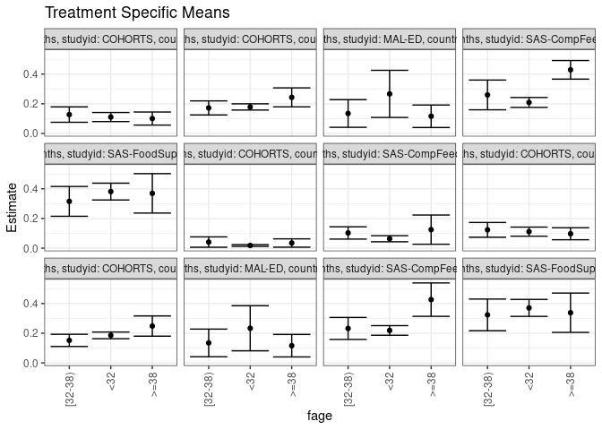

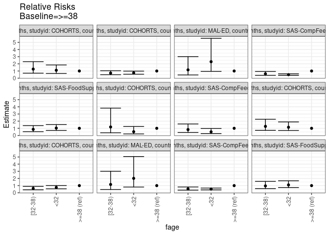

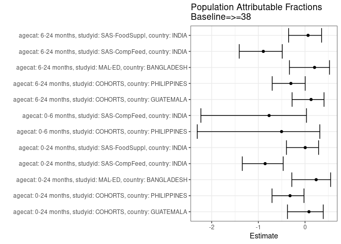

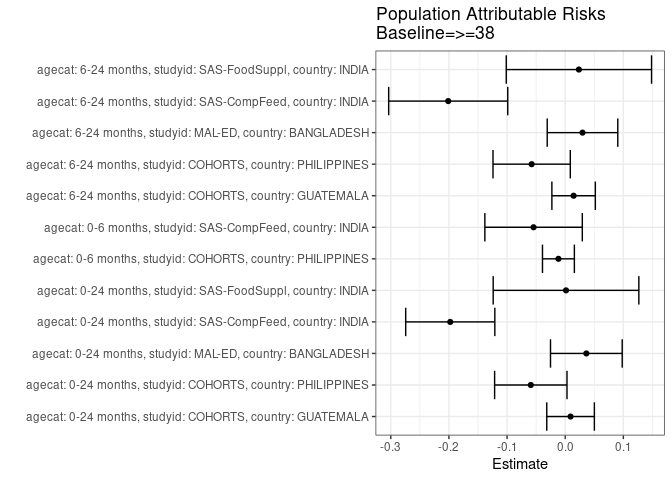

## Results Table

### Parameter: TSM

| agecat | studyid | country | intervention_level | baseline_level | estimate | ci_lower | ci_upper |
| --- | --- | --- | --- | --- | --- | --- | --- |
| 0-24 months | COHORTS | GUATEMALA | >=38 | NA | 0.1004976 | 0.0564029 | 0.1445922 |
| 0-24 months | COHORTS | GUATEMALA | <32 | NA | 0.1107817 | 0.0802490 | 0.1413143 |
| 0-24 months | COHORTS | GUATEMALA | [32-38) | NA | 0.1271190 | 0.0752514 | 0.1789866 |
| 0-24 months | COHORTS | PHILIPPINES | >=38 | NA | 0.2432222 | 0.1792884 | 0.3071560 |
| 0-24 months | COHORTS | PHILIPPINES | <32 | NA | 0.1788103 | 0.1578522 | 0.1997684 |
| 0-24 months | COHORTS | PHILIPPINES | [32-38) | NA | 0.1720981 | 0.1247267 | 0.2194695 |
| 0-24 months | MAL-ED | BANGLADESH | >=38 | NA | 0.1159420 | 0.0401494 | 0.1917347 |
| 0-24 months | MAL-ED | BANGLADESH | <32 | NA | 0.2666667 | 0.1078978 | 0.4254355 |
| 0-24 months | MAL-ED | BANGLADESH | [32-38) | NA | 0.1346154 | 0.0415386 | 0.2276921 |
| 0-24 months | SAS-CompFeed | INDIA | >=38 | NA | 0.4287924 | 0.3661200 | 0.4914648 |
| 0-24 months | SAS-CompFeed | INDIA | <32 | NA | 0.2089946 | 0.1755031 | 0.2424861 |
| 0-24 months | SAS-CompFeed | INDIA | [32-38) | NA | 0.2596405 | 0.1594565 | 0.3598245 |
| 0-24 months | SAS-FoodSuppl | INDIA | >=38 | NA | 0.3693987 | 0.2366050 | 0.5021923 |
| 0-24 months | SAS-FoodSuppl | INDIA | <32 | NA | 0.3814441 | 0.3248460 | 0.4380422 |
| 0-24 months | SAS-FoodSuppl | INDIA | [32-38) | NA | 0.3152980 | 0.2150362 | 0.4155599 |
| 0-6 months | COHORTS | PHILIPPINES | >=38 | NA | 0.0347927 | 0.0066753 | 0.0629101 |
| 0-6 months | COHORTS | PHILIPPINES | <32 | NA | 0.0181660 | 0.0120852 | 0.0242468 |
| 0-6 months | COHORTS | PHILIPPINES | [32-38) | NA | 0.0411980 | 0.0062872 | 0.0761087 |
| 0-6 months | SAS-CompFeed | INDIA | >=38 | NA | 0.1250000 | 0.0265956 | 0.2234044 |
| 0-6 months | SAS-CompFeed | INDIA | <32 | NA | 0.0635930 | 0.0431567 | 0.0840293 |
| 0-6 months | SAS-CompFeed | INDIA | [32-38) | NA | 0.1025641 | 0.0610899 | 0.1440383 |
| 6-24 months | COHORTS | GUATEMALA | >=38 | NA | 0.0972279 | 0.0566725 | 0.1377834 |
| 6-24 months | COHORTS | GUATEMALA | <32 | NA | 0.1115529 | 0.0809036 | 0.1422022 |
| 6-24 months | COHORTS | GUATEMALA | [32-38) | NA | 0.1235090 | 0.0739488 | 0.1730692 |
| 6-24 months | COHORTS | PHILIPPINES | >=38 | NA | 0.2482015 | 0.1799959 | 0.3164072 |
| 6-24 months | COHORTS | PHILIPPINES | <32 | NA | 0.1855023 | 0.1629548 | 0.2080498 |
| 6-24 months | COHORTS | PHILIPPINES | [32-38) | NA | 0.1516038 | 0.1105334 | 0.1926742 |
| 6-24 months | MAL-ED | BANGLADESH | >=38 | NA | 0.1159420 | 0.0401494 | 0.1917347 |
| 6-24 months | MAL-ED | BANGLADESH | <32 | NA | 0.2333333 | 0.0814808 | 0.3851858 |
| 6-24 months | MAL-ED | BANGLADESH | [32-38) | NA | 0.1346154 | 0.0415386 | 0.2276921 |
| 6-24 months | SAS-CompFeed | INDIA | >=38 | NA | 0.4262980 | 0.3137746 | 0.5388213 |
| 6-24 months | SAS-CompFeed | INDIA | <32 | NA | 0.2186359 | 0.1862255 | 0.2510463 |
| 6-24 months | SAS-CompFeed | INDIA | [32-38) | NA | 0.2321435 | 0.1582081 | 0.3060788 |
| 6-24 months | SAS-FoodSuppl | INDIA | >=38 | NA | 0.3380285 | 0.2057133 | 0.4703436 |
| 6-24 months | SAS-FoodSuppl | INDIA | <32 | NA | 0.3705953 | 0.3134010 | 0.4277895 |
| 6-24 months | SAS-FoodSuppl | INDIA | [32-38) | NA | 0.3234372 | 0.2166895 | 0.4301849 |

### Parameter: E(Y)

| agecat | studyid | country | intervention_level | baseline_level | estimate | ci_lower | ci_upper |
| --- | --- | --- | --- | --- | --- | --- | --- |
| 0-24 months | COHORTS | GUATEMALA | NA | NA | 0.1097276 | 0.0926320 | 0.1268233 |
| 0-24 months | COHORTS | PHILIPPINES | NA | NA | 0.1840762 | 0.1700627 | 0.1980897 |
| 0-24 months | MAL-ED | BANGLADESH | NA | NA | 0.1523179 | 0.0948144 | 0.2098214 |
| 0-24 months | SAS-CompFeed | INDIA | NA | NA | 0.2311258 | 0.1911027 | 0.2711489 |
| 0-24 months | SAS-FoodSuppl | INDIA | NA | NA | 0.3708134 | 0.3244530 | 0.4171738 |
| 0-6 months | COHORTS | PHILIPPINES | NA | NA | 0.0231450 | 0.0177070 | 0.0285830 |
| 0-6 months | SAS-CompFeed | INDIA | NA | NA | 0.0706196 | 0.0480792 | 0.0931600 |
| 6-24 months | COHORTS | GUATEMALA | NA | NA | 0.1116838 | 0.0935814 | 0.1297863 |
| 6-24 months | COHORTS | PHILIPPINES | NA | NA | 0.1905112 | 0.1757477 | 0.2052747 |
| 6-24 months | MAL-ED | BANGLADESH | NA | NA | 0.1456954 | 0.0892366 | 0.2021542 |
| 6-24 months | SAS-CompFeed | INDIA | NA | NA | 0.2251082 | 0.1905625 | 0.2596539 |
| 6-24 months | SAS-FoodSuppl | INDIA | NA | NA | 0.3615960 | 0.3145115 | 0.4086805 |

### Parameter: RR

| agecat | studyid | country | intervention_level | baseline_level | estimate | ci_lower | ci_upper |
| --- | --- | --- | --- | --- | --- | --- | --- |
| 0-24 months | COHORTS | GUATEMALA | >=38 | >=38 | 1.0000000 | 1.0000000 | 1.0000000 |
| 0-24 months | COHORTS | GUATEMALA | <32 | >=38 | 1.1023319 | 0.6580896 | 1.8464592 |
| 0-24 months | COHORTS | GUATEMALA | [32-38) | >=38 | 1.2648960 | 0.6949836 | 2.3021575 |
| 0-24 months | COHORTS | PHILIPPINES | >=38 | >=38 | 1.0000000 | 1.0000000 | 1.0000000 |
| 0-24 months | COHORTS | PHILIPPINES | <32 | >=38 | 0.7351725 | 0.5515954 | 0.9798462 |
| 0-24 months | COHORTS | PHILIPPINES | [32-38) | >=38 | 0.7075757 | 0.4838178 | 1.0348179 |
| 0-24 months | MAL-ED | BANGLADESH | >=38 | >=38 | 1.0000000 | 1.0000000 | 1.0000000 |
| 0-24 months | MAL-ED | BANGLADESH | <32 | >=38 | 2.3000000 | 0.9499965 | 5.5684414 |
| 0-24 months | MAL-ED | BANGLADESH | [32-38) | >=38 | 1.1610577 | 0.4483418 | 3.0067571 |
| 0-24 months | SAS-CompFeed | INDIA | >=38 | >=38 | 1.0000000 | 1.0000000 | 1.0000000 |
| 0-24 months | SAS-CompFeed | INDIA | <32 | >=38 | 0.4874028 | 0.3906131 | 0.6081761 |
| 0-24 months | SAS-CompFeed | INDIA | [32-38) | >=38 | 0.6055156 | 0.3926349 | 0.9338168 |
| 0-24 months | SAS-FoodSuppl | INDIA | >=38 | >=38 | 1.0000000 | 1.0000000 | 1.0000000 |
| 0-24 months | SAS-FoodSuppl | INDIA | <32 | >=38 | 1.0326081 | 0.7002093 | 1.5228013 |
| 0-24 months | SAS-FoodSuppl | INDIA | [32-38) | >=38 | 0.8535440 | 0.5290941 | 1.3769522 |
| 0-6 months | COHORTS | PHILIPPINES | >=38 | >=38 | 1.0000000 | 1.0000000 | 1.0000000 |
| 0-6 months | COHORTS | PHILIPPINES | <32 | >=38 | 0.5221210 | 0.2176966 | 1.2522487 |
| 0-6 months | COHORTS | PHILIPPINES | [32-38) | >=38 | 1.1840980 | 0.3671347 | 3.8190012 |
| 0-6 months | SAS-CompFeed | INDIA | >=38 | >=38 | 1.0000000 | 1.0000000 | 1.0000000 |
| 0-6 months | SAS-CompFeed | INDIA | <32 | >=38 | 0.5087440 | 0.2651710 | 0.9760514 |
| 0-6 months | SAS-CompFeed | INDIA | [32-38) | >=38 | 0.8205128 | 0.4199560 | 1.6031234 |
| 6-24 months | COHORTS | GUATEMALA | >=38 | >=38 | 1.0000000 | 1.0000000 | 1.0000000 |
| 6-24 months | COHORTS | GUATEMALA | <32 | >=38 | 1.1473334 | 0.6970388 | 1.8885230 |
| 6-24 months | COHORTS | GUATEMALA | [32-38) | >=38 | 1.2703032 | 0.7121022 | 2.2660657 |
| 6-24 months | COHORTS | PHILIPPINES | >=38 | >=38 | 1.0000000 | 1.0000000 | 1.0000000 |
| 6-24 months | COHORTS | PHILIPPINES | <32 | >=38 | 0.7473858 | 0.5536439 | 1.0089258 |
| 6-24 months | COHORTS | PHILIPPINES | [32-38) | >=38 | 0.6108093 | 0.4153811 | 0.8981825 |
| 6-24 months | MAL-ED | BANGLADESH | >=38 | >=38 | 1.0000000 | 1.0000000 | 1.0000000 |
| 6-24 months | MAL-ED | BANGLADESH | <32 | >=38 | 2.0125000 | 0.8000739 | 5.0622279 |
| 6-24 months | MAL-ED | BANGLADESH | [32-38) | >=38 | 1.1610577 | 0.4483418 | 3.0067571 |
| 6-24 months | SAS-CompFeed | INDIA | >=38 | >=38 | 1.0000000 | 1.0000000 | 1.0000000 |
| 6-24 months | SAS-CompFeed | INDIA | <32 | >=38 | 0.5128712 | 0.4016402 | 0.6549067 |
| 6-24 months | SAS-CompFeed | INDIA | [32-38) | >=38 | 0.5445568 | 0.3658048 | 0.8106569 |
| 6-24 months | SAS-FoodSuppl | INDIA | >=38 | >=38 | 1.0000000 | 1.0000000 | 1.0000000 |
| 6-24 months | SAS-FoodSuppl | INDIA | <32 | >=38 | 1.0963434 | 0.7202540 | 1.6688125 |
| 6-24 months | SAS-FoodSuppl | INDIA | [32-38) | >=38 | 0.9568342 | 0.5741205 | 1.5946684 |

### Parameter: PAR

| agecat | studyid | country | intervention_level | baseline_level | estimate | ci_lower | ci_upper |
| --- | --- | --- | --- | --- | --- | --- | --- |
| 0-24 months | COHORTS | GUATEMALA | >=38 | NA | 0.0092301 | -0.0317123 | 0.0501724 |
| 0-24 months | COHORTS | PHILIPPINES | >=38 | NA | -0.0591460 | -0.1213827 | 0.0030907 |
| 0-24 months | MAL-ED | BANGLADESH | >=38 | NA | 0.0363759 | -0.0252782 | 0.0980299 |
| 0-24 months | SAS-CompFeed | INDIA | >=38 | NA | -0.1976666 | -0.2743119 | -0.1210212 |
| 0-24 months | SAS-FoodSuppl | INDIA | >=38 | NA | 0.0014147 | -0.1238337 | 0.1266631 |
| 0-6 months | COHORTS | PHILIPPINES | >=38 | NA | -0.0116477 | -0.0390646 | 0.0157692 |
| 0-6 months | SAS-CompFeed | INDIA | >=38 | NA | -0.0543804 | -0.1381804 | 0.0294196 |
| 6-24 months | COHORTS | GUATEMALA | >=38 | NA | 0.0144559 | -0.0229058 | 0.0518176 |
| 6-24 months | COHORTS | PHILIPPINES | >=38 | NA | -0.0576903 | -0.1241504 | 0.0087697 |
| 6-24 months | MAL-ED | BANGLADESH | >=38 | NA | 0.0297533 | -0.0309275 | 0.0904341 |
| 6-24 months | SAS-CompFeed | INDIA | >=38 | NA | -0.2011897 | -0.3035764 | -0.0988030 |
| 6-24 months | SAS-FoodSuppl | INDIA | >=38 | NA | 0.0235676 | -0.1013758 | 0.1485109 |

### Parameter: PAF

| agecat | studyid | country | intervention_level | baseline_level | estimate | ci_lower | ci_upper |
| --- | --- | --- | --- | --- | --- | --- | --- |
| 0-24 months | COHORTS | GUATEMALA | >=38 | NA | 0.0841179 | -0.3764841 | 0.3905922 |
| 0-24 months | COHORTS | PHILIPPINES | >=38 | NA | -0.3213126 | -0.7074325 | -0.0225101 |
| 0-24 months | MAL-ED | BANGLADESH | >=38 | NA | 0.2388154 | -0.2830190 | 0.5484073 |
| 0-24 months | SAS-CompFeed | INDIA | >=38 | NA | -0.8552335 | -1.3447199 | -0.4679329 |
| 0-24 months | SAS-FoodSuppl | INDIA | >=38 | NA | 0.0038152 | -0.3982616 | 0.2902728 |
| 0-6 months | COHORTS | PHILIPPINES | >=38 | NA | -0.5032492 | -2.3104956 | 0.3173958 |
| 0-6 months | SAS-CompFeed | INDIA | >=38 | NA | -0.7700472 | -2.2322597 | 0.0306883 |
| 6-24 months | COHORTS | GUATEMALA | >=38 | NA | 0.1294360 | -0.2776281 | 0.4068057 |
| 6-24 months | COHORTS | PHILIPPINES | >=38 | NA | -0.3028185 | -0.7036022 | 0.0036781 |
| 6-24 months | MAL-ED | BANGLADESH | >=38 | NA | 0.2042161 | -0.3337776 | 0.5252042 |
| 6-24 months | SAS-CompFeed | INDIA | >=38 | NA | -0.8937467 | -1.4098562 | -0.4881703 |
| 6-24 months | SAS-FoodSuppl | INDIA | >=38 | NA | 0.0651765 | -0.3526834 | 0.3539545 |